# labjs mini-workshop

Work together in groups of two, at your own pace. I may occasionally stop you so we can all look at something together on the screen. Try to figure it out on your own, but please do ask me if you get stuck.

1

Open lab.js and build a basic Stroop experiment, just like the one in the article and the videos.

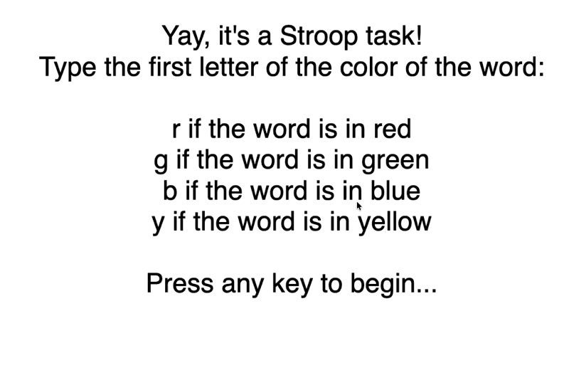

2

Download the data and open it in Excel or something similar. Can you identify the relevant columns and rows, and where they came from in the experiment?

3

Save your experiment — lab.js will save it as a `.json` text file. Give the file a human-readable name.

4

Add more trials, but instead of typing them all into lab.js, make a CSV file in Excel or Numbers (or similar) and upload that into lab.js.

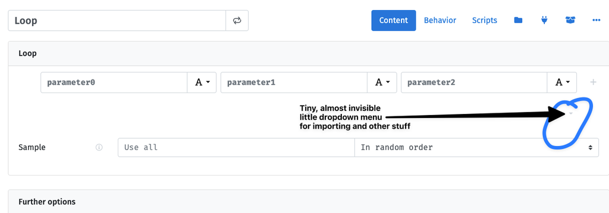

5

Save this new experiment. Give the file a human-readable name.

6

Add a label for the congruent and incongruent blocks. You can do this faster if you work in the CSV file, and then re-upload to lab.js.

7

Add a fixation cross (could be **+** or **x**). Add a timeout, so the experiment continues automatically if the participant does not respond within a certain amount of time.

8

Make the fixation cross flash briefly to one of the stimulus colors. Add a column indicating whether the color is the same as, or different from, the target color.

9

Divide the experiment into a practice round and a test round. Only the practice round should give feedback. Save the experiment. Give the file a human-readable name.

10

If you have lots of time left over: everybody in your group should run the experiment and download their data. Upload all the datasets from your group to UCloud, and use pandas to combine, clean, and analyze the results.